# 问题： 有哪些因素会让船上的人生还率更高？

## 简介：

#### 项目数据来自titanic-data.csv，通过已有数据分析出泰坦尼克号上哪一类群体的生还几率更高

## 数据整理：

#### 由于数据中出现了空值，现将年龄列用年龄均值填充，由于cabin确实值太多，将cabin列删除

#### 以下代码部分为加载数据并除去空值

```python
# -*- coding: UTF-8 -*-
# 加载样本数据,加载第三方库

import pandas as pd
import matplotlib
import numpy as np
import matplotlib.pyplot as plt
import matplotlib.cm as cm
import seaborn as sns

%matplotlib inline

raw_data = pd.read_csv('titanic-data.csv')


# 去掉空值, 年龄按均值填充, cabin
def remove_empty_cells(dataframe, list_of_columns, replace):
    for column in list_of_columns:
      dataframe[column] = dataframe[column].fillna(replace)
    return dataframe

lists = ['Age']

raw_data.Age.fillna(raw_data.Age.mean(),inplace=True)

new_data = remove_empty_cells(raw_data,lists,raw_data.Age.mean())

del raw_data['Cabin']

raw_data[0:10]
```

|  | PassengerId | Survived | Pclass | Name | Sex | Age | SibSp | Parch | Ticket | Fare | Embarked |
| --- | --- | --- | --- | --- | --- | --- | --- | --- | --- | --- | --- |
| 0 | 1 | 0 | 3 | Braund, Mr. Owen Harris | male | 22.000000 | 1 | 0 | A/5 21171 | 7.2500 | S |
| 1 | 2 | 1 | 1 | Cumings, Mrs. John Bradley (Florence Briggs Th... | female | 38.000000 | 1 | 0 | PC 17599 | 71.2833 | C |
| 2 | 3 | 1 | 3 | Heikkinen, Miss. Laina | female | 26.000000 | 0 | 0 | STON/O2. 3101282 | 7.9250 | S |
| 3 | 4 | 1 | 1 | Futrelle, Mrs. Jacques Heath (Lily May Peel) | female | 35.000000 | 1 | 0 | 113803 | 53.1000 | S |
| 4 | 5 | 0 | 3 | Allen, Mr. William Henry | male | 35.000000 | 0 | 0 | 373450 | 8.0500 | S |
| 5 | 6 | 0 | 3 | Moran, Mr. James | male | 29.699118 | 0 | 0 | 330877 | 8.4583 | Q |
| 6 | 7 | 0 | 1 | McCarthy, Mr. Timothy J | male | 54.000000 | 0 | 0 | 17463 | 51.8625 | S |
| 7 | 8 | 0 | 3 | Palsson, Master. Gosta Leonard | male | 2.000000 | 3 | 1 | 349909 | 21.0750 | S |
| 8 | 9 | 1 | 3 | Johnson, Mrs. Oscar W (Elisabeth Vilhelmina Berg) | female | 27.000000 | 0 | 2 | 347742 | 11.1333 | S |
| 9 | 10 | 1 | 2 | Nasser, Mrs. Nicholas (Adele Achem) | female | 14.000000 | 1 | 0 | 237736 | 30.0708 | C |

## 数据分析 part 1： 皮尔逊相关系数

#### 以下代码将根据数据呈现出来的相关性，利用皮尔逊积矩等方法来分析数据。

```python
#相关数据，可进行数学计算，用于皮尔逊相关系数的计算
raw_data.describe()
```

|  | PassengerId | Survived | Pclass | Age | SibSp | Parch | Fare |
| --- | --- | --- | --- | --- | --- | --- | --- |
| count | 891.000000 | 891.000000 | 891.000000 | 891.000000 | 891.000000 | 891.000000 | 891.000000 |
| mean | 446.000000 | 0.383838 | 2.308642 | 29.699118 | 0.523008 | 0.381594 | 32.204208 |
| std | 257.353842 | 0.486592 | 0.836071 | 13.002015 | 1.102743 | 0.806057 | 49.693429 |
| min | 1.000000 | 0.000000 | 1.000000 | 0.420000 | 0.000000 | 0.000000 | 0.000000 |
| 25% | 223.500000 | 0.000000 | 2.000000 | 22.000000 | 0.000000 | 0.000000 | 7.910400 |
| 50% | 446.000000 | 0.000000 | 3.000000 | 29.699118 | 0.000000 | 0.000000 | 14.454200 |
| 75% | 668.500000 | 1.000000 | 3.000000 | 35.000000 | 1.000000 | 0.000000 | 31.000000 |
| max | 891.000000 | 1.000000 | 3.000000 | 80.000000 | 8.000000 | 6.000000 | 512.329200 |

##### 以下为皮尔逊相关系数的数据和可视化图像

```python
# 皮尔逊积矩
raw_data.corr()
```

|  | PassengerId | Survived | Pclass | Age | SibSp | Parch | Fare |
| --- | --- | --- | --- | --- | --- | --- | --- |
| PassengerId | 1.000000 | -0.005007 | -0.035144 | 0.033207 | -0.057527 | -0.001652 | 0.012658 |
| Survived | -0.005007 | 1.000000 | -0.338481 | -0.069809 | -0.035322 | 0.081629 | 0.257307 |
| Pclass | -0.035144 | -0.338481 | 1.000000 | -0.331339 | 0.083081 | 0.018443 | -0.549500 |
| Age | 0.033207 | -0.069809 | -0.331339 | 1.000000 | -0.232625 | -0.179191 | 0.091566 |
| SibSp | -0.057527 | -0.035322 | 0.083081 | -0.232625 | 1.000000 | 0.414838 | 0.159651 |
| Parch | -0.001652 | 0.081629 | 0.018443 | -0.179191 | 0.414838 | 1.000000 | 0.216225 |
| Fare | 0.012658 | 0.257307 | -0.549500 | 0.091566 | 0.159651 | 0.216225 | 1.000000 |

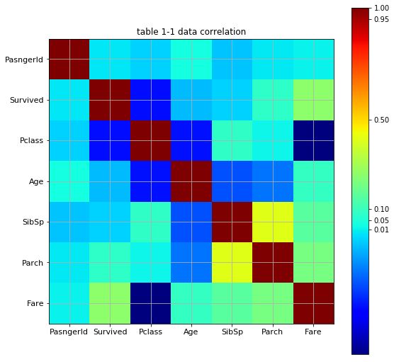

```python
# 图形化皮尔逊积矩表
def correlation_matrix(df,labels):

    fig = plt.figure()
    fig.set_figheight(9)
    fig.set_figwidth(9)
    ax1 = fig.add_subplot(111) #一行一列的第一个
    cmap = cm.get_cmap('jet', 999)
    cax = ax1.imshow(df.corr(), interpolation="nearest", cmap=cmap)
    ax1.grid(True)
    plt.title('table 1-1 data correlation')
    #ax1.set_xticks(range(len(labels)))
    ax1.set_xticklabels(labels,fontsize=11)
    ax1.set_yticklabels(labels,fontsize=11)
    # Add colorbar, make sure to specify tick locations to match desired ticklabels
    fig.colorbar(cax, ticks=[.01,.05,.10,.50,.95,1])
    plt.show()

labels=['','PasngerId','Survived','Pclass','Age','SibSp','Parch','Fare']
correlation_matrix(raw_data,labels)
```

#### 从图1-1我们可以观察到，颜色对应越深，代表相关系数越高，从Survived列上观察，可得Survived和PClass的颜色最显著，

#### 而PClass于Age，Survived，Fare相关性比较显著。

### Part 1总结：

#### 由皮尔逊积矩得出相关系数，几个强关联的数据为Fare和Pclass（-0.549500）为强负相关，

#### 即Fare（票价）越高，船仓等级越低（Pclass，等级越低越豪华，1最豪华）。

#### 由于票价包含了多人组团购买船票的因素，我们利用船舱等级来分析其与生还概率的关系。

#### 值得注意的是，这个相关系数只能反映两个变量的线性相关性。所以哪怕相关系数接近于0，不表示两个变量没有相关性。

## 数据分析 part 2： PClass于生还概率的关系

#### 由皮尔逊相关系数的结果，我们先观察PClass与生还概率的关系，以下代码将分析生还率与Pclass相关的数据分布。

#### 先计算每个PClass分类下的人数总量和生还者总量，然后将他们用可视化的图表展示出来观察其与生还率的关系。

```python
#get unique survived_ppl set of passenger id
survived_ppl = set()
for indexs in raw_data.index:
    if raw_data.loc[indexs].values[1] == 1:
        survived_ppl.add(raw_data.loc[indexs].values[0])

raw_data.groupby('Survived').size()
```

```
Survived
0    549
1    342
dtype: int64
```

```python
# 每个Pclass的总人数
raw_data.groupby('Pclass').size()
```

```
Pclass
1    216
2    184
3    491
dtype: int64
```

```python
# 每个Pclass的遇难者和生还者人数
raw_data.groupby(['Pclass', 'Survived']).size()
```

```
Pclass  Survived
1       0            80
        1           136
2       0            97
        1            87
3       0           372
        1           119
dtype: int64
```

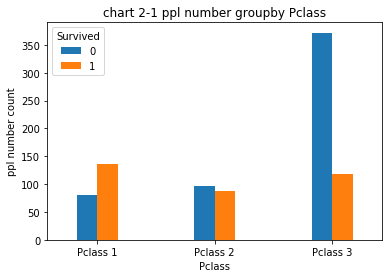

```python
# 绘制分组条形图
ind = np.arange(3)

grouped_data = raw_data.groupby(['Pclass', 'Survived']).size().unstack()
grouped_data.plot(kind='bar', stacked=False, width = 0.35)
plt.xticks(ind, ('Pclass 1', 'Pclass 2', 'Pclass 3'), rotation=0)
plt.title('chart 2-1 ppl number groupby Pclass')
plt.ylabel('ppl number count')
plt.show()
```

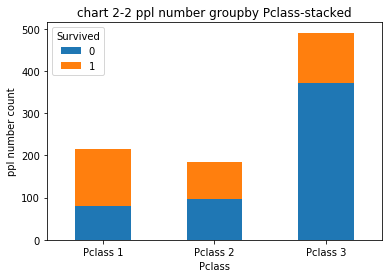

```python
# 绘制堆栈条形图
grouped_data.plot(kind='bar', stacked=True)
plt.xticks(ind, ('Pclass 1', 'Pclass 2', 'Pclass 3'), rotation=0)
plt.title('chart 2-2 ppl number groupby Pclass-stacked')
plt.ylabel('ppl number count')
plt.show()
```

### Part 2 总结：

#### 由chart 2-1 可以得出，PClass1的生还者数量显著大于死亡者数量，为3个Class中最高的。

#### 由chart 2-2 同样可以得出Pclass1点生还者数量最多，但Pclass1的总人数少于Pclass3稍多于Pclass2

#### 由上可以得出，在PClass1上有助于提高生还率。

## 数据分析 Part 3：生还率于其他数据的相关性

#### 我们注意到年龄是最易区别个体的变量，而且年龄与PClass也有一定相关性，所以接下来分析年龄是否与生还率有一定联系

#### 首先我们按照生还与否以及年龄进行分类，为了减少数据和可视化图像的复杂度，我们将年龄分类的bin size设为10，

#### 下面代码为不同年龄段段人数

```python
bins=np.arange(0,90,10)
raw_data['Age_group'] = pd.cut(raw_data['Age'], bins)
raw_data.groupby('Age_group').size()
```

```
Age_group
(0, 10]      64
(10, 20]    115
(20, 30]    407
(30, 40]    155
(40, 50]     86
(50, 60]     42
(60, 70]     17
(70, 80]      5
dtype: int64
```

#### 下面代码为不同年龄段和生还与否的人数

```python
raw_data.groupby(['Age_group', 'Survived']).size()
```

```
Age_group  Survived
(0, 10]    0            26
           1            38
(10, 20]   0            71
           1            44
(20, 30]   0           271
           1           136
(30, 40]   0            86
           1            69
(40, 50]   0            53
           1            33
(50, 60]   0            25
           1            17
(60, 70]   0            13
           1             4
(70, 80]   0             4
           1             1
dtype: int64
```

#### 下面代码为生还者在不同年龄段段分布数量

```python
raw_data['Surviver_Age_group'] = pd.cut(raw_data.loc[raw_data.Survived == 1]['Age'], bins)

raw_data.groupby('Surviver_Age_group').size()
```

```
Surviver_Age_group
(0, 10]      38
(10, 20]     44
(20, 30]    136
(30, 40]     69
(40, 50]     33
(50, 60]     17
(60, 70]      4
(70, 80]      1
dtype: int64
```

#### 下面我们按照年龄分组，画出生还者与死亡人数的柱状图

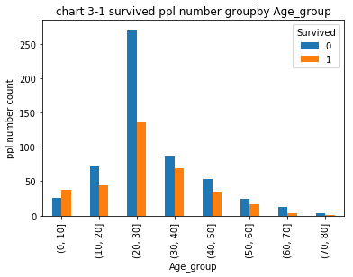

```python
# 对年龄分组
bins=np.arange(0,90,10)
raw_data['Age_group'] = pd.cut(raw_data['Age'], bins)

# 绘制不同分组的生还者和遇难者条形图
grouped = raw_data.groupby(['Age_group', 'Survived']).size()
grouped.unstack().plot(kind='bar', stacked=False)
plt.ylabel('ppl number count')
plt.title('chart 3-1 survived ppl number groupby Age_group')
plt.show()
```

#### 下面代码求不同年龄段的生还率，由于死亡者为0，生还者为1，每个年龄组的survived列的均值即为生还率。

```python
raw_data.groupby('Age_group')['Survived'].mean()
```

```
Age_group
(0, 10]     0.593750
(10, 20]    0.382609
(20, 30]    0.334152
(30, 40]    0.445161
(40, 50]    0.383721
(50, 60]    0.404762
(60, 70]    0.235294
(70, 80]    0.200000
Name: Survived, dtype: float64
```

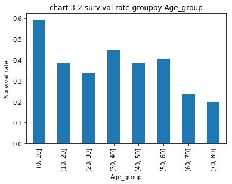

```python
raw_data.groupby('Age_group')['Survived'].mean().plot(kind='bar', stacked=False)
plt.ylabel('Survival rate')
plt.title('chart 3-2 survival rate groupby Age_group')
plt.show()
```

### Part 3 总结：

#### 由3-1可以分析得出，年龄在20-30岁人数最多，虽然生还者最多，但是死亡人数也是最多的，而年龄在0-10岁，

#### 生还人数比死亡人数要多，由3-2更可以看出，0-10岁分组多生还率为0.59（取两位小数），是最高的，所以结论为，

#### 年龄在0-10岁的生还概率最高。

## 结论

#### 本报告的结论为，当乘客在PClass为1的情况下生还概率比其他PClass高，年龄段在0-10之间的获救概率大于其他年龄层。

#### 报告中使用的数据是乘客总体数据，数据中缺失的部分如年龄，按照均值填充，Cabin由于缺失部分太多将其删除，

#### 缺失的数据会对总体造成相应的影响，但由于数目不大，而且按照均值填充，对结论的产生影响不大。

#### 数据中Fare的数据应当与Pclass成正相关，但有些数据不符，据观察是由于其中包含了多人的票价。

#### 报告并没有讨论的所有变量，只讨论了几个相关性比较显著的变量，其他变量比如性别，家属或许会有一定相关性。

## 参考文献：

[Calculation and Visualization of Correlation Matrix with Pandas](https://datascience.stackexchange.com/questions/10459/calculation-and-visualization-of-correlation-matrix-with-pandas)

[Matplotlib Color map](https://matplotlib.org/api/cm_api.html)

[matplotlib add_subplot](http://www.codeweblog.com/matplotlib-pyplot中add_subplot方法参数111的含义/)

[matplotlib imshow](https://matplotlib.org/devdocs/api/_as_gen/matplotlib.pyplot.imshow.html)

[What does matplotlib `imshow(interpolation='nearest')` do?](https://stackoverflow.com/questions/12473511/what-does-matplotlib-imshowinterpolation-nearest-do)

[matplotlib绘图常见设置](https://www.cnblogs.com/nju2014/p/5707980.html)